# Core Affect

As suggested above, core affect tends to become an emotional experience via appraisal or attribution regarding what is happening during a particular episode.

From: [International Encyclopedia of Education (Third Edition), 2010](https://www.sciencedirect.com/science/article/pii/B9780080448947006059)

## Related terms:

- [Working Memory](https://www.sciencedirect.com/topics/psychology/working-memory)
- [Amygdala](https://www.sciencedirect.com/topics/psychology/amygdala)
- [Avoidance](https://www.sciencedirect.com/topics/psychology/avoidance)
- [Emotional Episode](https://www.sciencedirect.com/topics/psychology/emotional-episode)
- [Facial Expression](https://www.sciencedirect.com/topics/psychology/facial-expression)
- [Insula](https://www.sciencedirect.com/topics/psychology/insula)
- [Neurofeedback](https://www.sciencedirect.com/topics/psychology/neurofeedback)

[View all Topics](https://www.sciencedirect.com/topics)

## [Emotion in Educational Contexts](https://www.sciencedirect.com/science/article/pii/B9780080448947006059)

P.A. Schutz, ... M. Lynde, in [International Encyclopedia of Education (Third Edition)](https://www.sciencedirect.com/referencework/9780080448947/international-encyclopedia-of-education), 2010

### Core Affect

Core affect is essentially how we feel at any particular point in time. Researchers in this area suggest that core affect is fundamentally a combination of two types of feeling continuums – valiance (pleasant to unpleasant) and arousal (low activation to high activation) (Linnenbrink, 2007; Russell, 2003; Russell and Barrett, 1999). Thus, at any particular point in time we may feel calm (low activation and pleasant), tense (high activation and unpleasant), or happy (pleasant, high activation). Mood, which is one example of core affect, can be viewed as a prolonged core affect without an object. Russell (2003) suggests that core affect is object free but can become directed at an object through attributions or appraisals. In these instances, the affect experience is usually described as an emotional experience.

[View chapter](https://www.sciencedirect.com/science/article/pii/B9780080448947006059)[Purchase book](https://www.elsevier.com/books/T/A/9780080448947)

## [PRODUCT EMOTION](https://www.sciencedirect.com/science/article/pii/B9780080450896500186)

PIETER M.A. DESMET, in [Product Experience](https://www.sciencedirect.com/book/9780080450896/product-experience), 2008

### 2.2 Attributed affect: Emotions

Core affect can account for an infinite number of emotional states and provides a basis for discussing similarities and differences among affective states. Note, however, that not all affective states are emotions. Two eliciting conditions distinguish emotions from other types of affective states. An emotion is experienced when (1) some stimulus excites a substantial and acute change, or jump, in core affect (Ekman, 1994a; Russell, 2003); and when (2) this change is attributed to some antecedent or ‘object’ (Frijda, 1994b). All emotions, including product emotions, imply and involve a relation between the person who experiences them and a particular object (Frijda, 1994b). Note that this object is not necessarily a physical object, but can also be a person, an animal, a company, etc. One is not just angry, but angry at someone, afraid of something, proud of something, in love with someone, and so on. So we are angry at our printer for a bad quality print, satisfied with our toaster for making the perfect toast, and bored by our telephone for its tedious ring tone.

The distinction between stimulus and object is important because they are not necessarily the same. One day my sister and I were picking flowers in the meadow next to our parents’ house. At one point in time my sister bent over to pick a flower and, without us realizing it, her back touched the electric cattle fence. The resulting shock gave her a big fright, and, not knowing what hit her, she became angry with me because she concluded that I must have kicked her in the back. Although the electric fence was the actual emotional stimulus, the object of her emotion was me. This example illustrates that the object is whatever one believes is making him or her experience the emotion, and that in some cases we can misattribute an acute change in core affect due to a particular stimulus to another object (see Schwarz and Clore, 1983). One can, for example, be angry at a colleague for some mistake that he was actually not responsible for. The same can also apply to product emotions. One can be angry at the television set because it appears to be broken as it shows a white signal. But the objective facts might tell another story; perhaps the television only appears to be broken because of an interruption in the signal supply; or one should actually blame oneself for accidentally disconnecting the signal cable. One can be irritated by the call centre operator when the irritation should actually be attributed to the company who hired the person. The retail industry is known for experimenting with intentionally generated misattribution effects. Supermarkets, for example, sometimes distribute the fragrance of freshly baked bread to generate pleasant feelings that the customer tends to misattribute to the bread that is for sale.

[View chapter](https://www.sciencedirect.com/science/article/pii/B9780080450896500186)[Purchase book](https://www.elsevier.com/books/T/A/9780080450896)

## [Sport and the Brain: The Science of Preparing, Enduring and Winning, Part C](https://www.sciencedirect.com/science/article/pii/S0079612318300980)

Nathan Wood, ... Lee Moore, in [Progress in Brain Research](https://www.sciencedirect.com/bookseries/progress-in-brain-research), 2018

### 3.3 Core Affect

Demand resource evaluation score accounted for a significant proportion of variance in core affect, *R*<sup>2</sup> = 0.26, *β* = 0.53, *P* = 0.002, *95% CI* = 0.55–2.12. Evaluating the pressurized Wingate test as more of a challenge (i.e., coping resources match or exceed task demands) was related to a more positive affective response (i.e., greater pleasure) than evaluating the test as more of a threat (i.e., task demands exceed coping resources). However, challenge/threat index failed to account for a significant proportion of variance in core affect, *R*<sup>2</sup> = 0.04, *β* = 0.27, *P* = 0.135, *95% CI* = − 0.12 to 0.83.

[View chapter](https://www.sciencedirect.com/science/article/pii/S0079612318300980)[Purchase book](https://www.elsevier.com/books/T/A/9780444641878)

## [Epigenetics and Down syndrome](https://www.sciencedirect.com/science/article/pii/B9780128002261000095)

A.D. Dekker, ... M.G. Rots, in [Neuropsychiatric Disorders and Epigenetics](https://www.sciencedirect.com/book/9780128002261/neuropsychiatric-disorders-and-epigenetics), 2017

### 9.4.2 Histone Core Variants and Constitutive Chromatin Proteins

In addition to histone tail modifications, histone core variants can also influence gene expression. Incorporation of different histone variants into the nucleosomal core affects the [chromatin structure](https://www.sciencedirect.com/topics/biochemistry-genetics-and-molecular-biology/chromatin-structure) [96]. Most variants have been discovered for [H2A](https://www.sciencedirect.com/topics/biochemistry-genetics-and-molecular-biology/histone) and H3 and were reported to have a diverse role in [gene expression regulation](https://www.sciencedirect.com/topics/biochemistry-genetics-and-molecular-biology/dosage-compensation). Incorporation of macroH2A, for instance, is associated with [gene repression](https://www.sciencedirect.com/topics/biochemistry-genetics-and-molecular-biology/gene-repression) [96,97]. HSA21 encodes the H2A histone family member Z pseudogene 1 (H2AFZP) and the [H2B histone](https://www.sciencedirect.com/topics/biochemistry-genetics-and-molecular-biology/histone-h2b) family member S pseudogene (H2BFS) [24,46,47,98]. DNA hypermethylation of the *H2BFS* gene has been reported in three villi samples of DS fetuses compared to non-DS controls [70]. Whereas H2BFS has been described as a component of the nucleosomal core, it is currently unknown whether the [H2AFZP](https://www.sciencedirect.com/topics/biochemistry-genetics-and-molecular-biology/pseudogene) encodes a protein [24,48]. The effects of both on gene regulation need to be established as well.

Besides these histone variants, two HSA21-encoded constitutive chromatin proteins contribute to nucleosome assembly: chromatin assembly factor 1B (CHAF1B) and [HMGN1](https://www.sciencedirect.com/topics/biochemistry-genetics-and-molecular-biology/high-mobility-group). The [CHAF1B](https://www.sciencedirect.com/topics/biochemistry-genetics-and-molecular-biology/chromatin-remodeling) protein is involved in nucleosome assembly on to newly replicated DNA by recruiting H3 and H4 [99,100]. CHAF1B forms a multiprotein complex with the methyl-CpG binding protein 1 (MBD1) and heterochromatin protein 1 (HP1), which, again, demonstrates the involvement of epigenetics in DS [49]. HMGN1 affects posttranslational [histone modifications](https://www.sciencedirect.com/topics/biochemistry-genetics-and-molecular-biology/histone-modification), in particular it inhibits phosphorylation of H3S10 and H3S28 and enhances H3K14 acetylation via CBP/P300 [50,51], and has been described to regulate MECP2 expression. MECP2 is highly expressed in the brain and can activate or repress [gene transcription](https://www.sciencedirect.com/topics/biochemistry-genetics-and-molecular-biology/genetic-transcription) [101]. Altered MECP2 activity may result in [intellectual disability](https://www.sciencedirect.com/topics/biochemistry-genetics-and-molecular-biology/mental-retardation) [51,102]. Abuhatzira et al. [51] reported transcript levels of *HMGN1* to be increased with 50% and transcript levels of *MECP2* to be decreased with 30% in brain tissue of DS patients compared to non-DS age-matched controls. In mice, it was found that altered HMGN1 protein levels resulted in histone modifications in the *MECP2* promoter and a modified chromatin structure. Therefore, overexpressed HMGN1 might disturb normal [learning and memory](https://www.sciencedirect.com/topics/psychology/learning-and-memory) processes through reduced MECP2 [protein expression](https://www.sciencedirect.com/topics/biochemistry-genetics-and-molecular-biology/protein-expression) and subsequently altered [epigenetic](https://www.sciencedirect.com/topics/biochemistry-genetics-and-molecular-biology/epigenetics) marks.

[View chapter](https://www.sciencedirect.com/science/article/pii/B9780128002261000095)[Purchase book](https://www.elsevier.com/books/T/A/9780128002261)

## [Cross-Cultural Similarities and Differences in Affective Processing and Expression](https://www.sciencedirect.com/science/article/pii/B9780128018514000045)

James A. Russell, in [Emotions and Affect in Human Factors and Human-Computer Interaction](https://www.sciencedirect.com/book/9780128018514/emotions-and-affect-in-human-factors-and-human-computer-interaction), 2017

### Subjective conscious experience

To most people, emotion simply is a conscious experience. I don’t agree. (For example, a man can honestly deny experiencing jealousy but later realize that he was in fact jealous. Further, subliminal threat stimuli can elicit the same changes in peripheral physiology as do supraliminal threats.) Still, conscious experience is important and pervasive in the study of emotion through verbal reports and the assumptions of experimenters.

The conscious experiences associated with emotion are heterogeneous. Without claiming to be exhaustive, I distinguish four kinds of emotional conscious experiences: Emotional Metaexperience, Core Affect, Perception of Affective Quality, and Attributed Affect. Here I focus on the first two.<sup>a</sup> The prototypical conscious emotional experience includes all four, but they can be separate. Distinguishing Emotional Metaexperience from Core Affect reconciles two traditions that emerged early in the psychology of conscious emotional experience: the categorical (anger, fear, joy, and so on) and the dimensional (valence, activation, and so on). Both traditions are needed and can be reconciled.

*Emotional Metaexperience*. The focus of much writing on emotion is the conscious subjective experience of having a specific emotion such as anger, jealousy, fear, love, and so on. On this traditional account, to experience anger or some other specific emotion is a simple reading of an inner biologically given signal. Instead, on my account, it is a psychologically constructed experience, the end product of an information processing stream that includes attention, memory, and a categorization of one’s current state based on available information. Based on his physiological research, Levenson (2011) offered an account of the feeling of a specific emotion I find indistinguishable from my account of emotional metaexperience. Based on his [neuroscience research](https://www.sciencedirect.com/topics/psychology/neuroscience-research), LeDoux (2015) offered a similar account—the interpreter theory of consciousness—for emotional metaexperience.

The mental categories we use in this process are not innate; rather, different categories are available to different individuals. English speakers may categorize a certain emotional state as *anger*; Ilongot speakers may categorize similar states as *liget* (Rosaldo, 1984). Different languages lexicalize different categories. One indication is that different languages recognize different numbers of categories, ranging from seven (Howell, 1984) to hundreds (Russell, 1991). Over the course of development, children similarly increase the number of different emotion categories they use (Widen, 2016). Thus, the number of potential categories is large and indeterminate. Categorization is a universal process, but the categories into which emotions are divided vary with language.

Some writers have attempted to reduce the number of categories by considering some to be “basic” and then defining the remainder as subcategories or blends of the basic ones. Still, there is no agreement on the number of such basic emotions, which emotions are basic, or what makes something basic (Ortony and Turner, 1990). Witness the disagreement over how many emotions are basic: Ekman (1972) listed six, but Ekman and Cordaro (2011) listed 21. The concept of “basic” may be of little use any more.

Moreover, different languages recognize different categories. Some languages make distinctions between emotions that English does not. There is no single word for shame in Chinese, but instead a set of types of shame. One might think that Chinese speakers recognize all these as subtypes of shame, but there is no evidence to support that thought. Conversely, English makes some distinctions that other languages do not. English distinguishes anger from sadness as qualitatively different (basic) emotions; some [African languages](https://www.sciencedirect.com/topics/social-sciences/african-languages) use the same word for the two (Leff, 1973). Similarly, the Ilongot term *liget* includes both anger and grief (Rosaldo, 1984). English distinguishes shame from embarrassment, but many non-Western languages do not (Levy, 1973). In other cases, English has a word for an emotion, whereas other languages do not (Leff, 1973; Levy 1973). [Tahitian](https://www.sciencedirect.com/topics/social-sciences/tahitian) lacks words equivalent to sadness and guilt (Levy, 1973). Ekman (1972) found no words for disgust or surprise in the Fore language of Papua New Guinea.

A few paragraphs before, readers might have thought that perhaps *liget* could simply be translated as *anger*. Anthropologists and cross-cultural psychologists often seek translations for English emotion words, but more careful study revealed differences. Anthropologists have reported such findings (Davitz, 1969; Levy, 1973; Rosaldo, 1980; Wikan, 1989). More experimental approaches have likewise found differences between what had been assumed translation equivalents (Han et al., 2015; Hurtado-de-Mendoza et al., 2013; Russell and Sato, 1995).

My term for conscious emotional experience as categorized is Emotional Metaexperience. On my account, the experience of anger, for example, is not the recurrence of the same, simple, irreducible mental quale. Although the existence of such qualia is sometimes assumed, no evidence for the assumption has been offered. Instead, Emotional Metaexperience is a complex form of self-perception. It is a metaexperience in that it depends on other aspects of experience, some of which are themselves consciously accessible. Like all perceptions, Emotional Metaexperiences are intentional mental states; that is, they include a representation of something: what one is angry about, jealous of, afraid of, or in love with. Like all perceptions, Emotional Metaexperiences are interpretations. The raw data on which the interpretation is based are both top-down (such as concepts, stored knowledge, expectations, attributions, appraisals, and memories) and bottom-up (from both the internal world via somatosensory feedback and the external world).

*Core Affect*. Core Affect is an aspect of subjective emotional experience. It is a neurophysiological state consciously accessible as simply feeling good or bad, energized or quiescent. At any point in time, a person can answer the question, how do you feel? Studies of their answers have led to the concept of Core Affect (Russell, 2003). Core Affect is, at a psychological level, the most elementary simple primitive affective feeling. A map of Core Affect is seen in Fig. 4.1, which shows a circumplex representation of self-reported moods and feelings. A person’s Core Affect at any one moment in time is represented by one point somewhere inside the space. The space, in turn, is characterized by two bipolar dimensions—valence and activation—in the dimensional tradition in the psychology of emotion. In this two-dimensional Cartesian space, a person’s basic affective feeling for each moment in time is placed at a single point. Like a flat map of earth, longitude and latitude do not tell everything about each place on the map, but are basic ingredients.

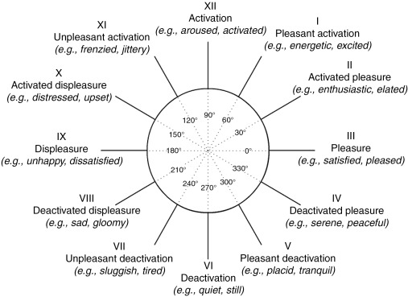

[Sign in to download full-size image](https://www.sciencedirect.com/user/login?returnURL=https%3A%2F%2Fwww.sciencedirect.com%2Ftopics%2Fpsychology%2Fcore-affect)

Figure 4.1. A representation of Core Affect by dividing the space into 12 segments.

Reprinted from Yik, M., Russell, J.A., Steiger, J.H. 2011. A 12-point circumplex structure of core affect. *Emotion 11*, 705–731. by permission.

The person thus has only one Core Affect at a time. The center can be thought of as an adaptation level (a neutral point midway between pleasure and displeasure and midway between low and high arousal), with distance from the center representing intensity or extremity of feeling. Core Affect can be extremely intense at times, milder at other times. When core affect lingers and is mild, we often call it mood.

The important feature of Core Affect is that it is pancultural. That is, in cultures and languages in which dimensions have been studied, valence and activation commonly emerge (Fontaine et al., 2013; Russell, 1983; Russell et al., 1989; Västfjäll et al., 2002).

Core Affect is part of (but not the whole of) emotional episodes, but is not synonymous with emotion. Thus, Core Affect is neither a substitute term for *emotion*, nor the essence of emotion, nor an additional discrete emotion. For example, whereas emotional episodes are said to begin and then, after a short time, end, one is always in some state of Core Affect, which simply varies over time (sometimes slowly, sometimes rapidly) without beginning or end. An analogy is body temperature: one always has a body temperature, but one is conscious of it only at times.

Emotional episodes (and emotional metaexperiences) are typically directed at something (one is angry with, afraid of, or sad about something). In contrast, Core Affect is not necessarily directed at anything. Like mood, Core Affect per se can be free-floating (as in feeling down but not about anything and not knowing why), but it can come to be directed at something. Still, the everyday concept of mood typically implies a long-lasting and mild state, whereas Core Affect has neither implication. Thus, mood can be thought of as a lingering Core Affect.

Core Affect is “a neurophysiological state that is consciously accessible as a simple, non-reflective feeling that is an integral blend of hedonic (pleasure–displeasure) and arousal (sleepy–activated) values” (Russell, 2003, p. 147). This seemingly simple definition contains a series of empirical proposals. Calling Core Affect a neurophysiological state is a promissory note so far left unfulfilled. The neural basis of Core Affect is an active research concern (Gerber et al., 2008; Posner et al., 2005, 2009).

This neurophysiological state has important functions. Core Affect is a continuous assessment of one’s current state, and it influences other psychological processes accordingly. A change in Core Affect evokes a search for its cause and therefore facilitates attention to and accessibility of like-valenced material. Core Affect thus guides cognitive processing according to the principle of mood congruency. When Core Affect is positive, then events encountered, remembered, or envisioned tend to seem more positive—provided that the Core Affect is not attributed elsewhere (Schwarz and Clore, 1983). Core Affect is part of the information used to estimate affective quality and thus is implicated in incidental acquisition of preferences and attitudes. Core Affect influences behavior from reflexes to complex decision making. Core Affect is a background state continuously changing in response to a host of events, most beyond conscious monitoring. Core Affect in turn provides a powerful bias in processing of new information. In this way, Core Affect is involved in one’s current state, including what are conventionally distinguished as cognitive state, motivational state, mood state, and so on, including past, present, and forecasts of the future.

One can seek to alter or maintain Core Affect directly—*affect regulation*—from the morning coffee to the evening brandy. People generally (but not always) seek behavioral options that maximize pleasure and minimize displeasure. Decisions thus involve predictions of future Core Affect. Core Affect is involved in motivation, reward, and reinforcement. An intriguing question is which of these functions requires conscious attention and which do not.

[View chapter](https://www.sciencedirect.com/science/article/pii/B9780128018514000045)[Purchase book](https://www.elsevier.com/books/T/A/9780128018514)

## [Concept profiling – navigating beyond liking](https://www.sciencedirect.com/science/article/pii/B9780128211243000120)

David M.H. Thomson, Toby Coates, in [Emotion Measurement (Second Edition)](https://www.sciencedirect.com/book/9780128211250/emotion-measurement), 2021

### 12.2.3 Characteristics of core affect

The circumplex model, and the two dimensions that define it, acquired significant additional meaning when James Russell and Lisa Feldman Barrett proclaimed that valence and arousal are effectively ‘one feeling’ which they termed core affect (Russell & Barrett, 1999), and subsequently defined as …

> a neurophysiological state consciously accessible as a simple primitive non-reflective feeling most evident in mood and emotion but always available to consciousness. Although one feeling, it can be characterized by two pan-cultural [bipolar dimensions](https://www.sciencedirect.com/topics/psychology/bipolar-dimension): pleasure – displeasure and activation.

> Russell and Barrett (2009)

Core affect is characterized as follows:

**•**

Primal – developed at an early stage of animal evolution

**•**

Universal – common across many higher and lower species

**•**

Fundamental – involved in survival

**•**

Elementary, consciously accessible affective feeling

**•**

Fundamental motivational force – driving attraction and avoidance behaviors

**•**

Psychophysiological – the physiological bases of psychological processes

**•**

Feedback controlled – body ↔ mind feedback mechanisms

**•**

Non-cognitive – arises autonomically, requiring no thought

**•**

A ‘state of being’ – people are constantly in a state of core affect although not always aware of it

**•**

Essentially a ‘barometer’ of one’s inner state … it’s ‘*how you are*’!

**•**

Many influences – internal, external - some are obvious, others are not

**•**

Influences various psychological processes including mood and emotion

**•**

Can remain stable (as in mood) or change rapidly (as in emotion)

**•**

A fundamental aspect of consciousness!

(*Since affect is ‘core’ by definition, the expression ‘core affect’ is simply referred to as ‘affect’ hereafter*.)

Among most psychologists, it’s generally agreed that affect is present from birth and that valence and arousal are basic features of human experience that are with us constantly, even when completely still or asleep. Exactly why an individual should be in a particular state of affect is likely to depend on various factors including, of course, their fundamental dispositions. For example, some people are characteristically joyous and energetic while others are inherently miserable and lethargic. Some people are more susceptible than others to diurnal or seasonal influences, presumably causing affect to fluctuate more dramatically. Affect may also be influenced by external stimuli (other people, other living things, inanimate objects, places, events, etc.) and again, some people will be influenced to a greater or lesser extent than others by routine fluctuations in these stimuli. Positively or negatively valanced thoughts may also influence affect.

Bearing in mind these inherent differences in affect within and across individuals, and if the circumplex model is thought of as a two-dimensional map, then different people would surely ‘average out’ at different positions on the map. If this idea is extended to a relatively large population of people plotted across multiple occasions, then it should be possible to create a response surface model of human affect, where the third axis is frequency of occurrence (Fig. 12.3). Taken at face value, the shape of the response surface in Fig. 12.3 supports the general finding that for much of the time, the state of affect of most people is slightly activated and somewhat pleasant (Mackinnona et al., 1999; Thomson & Crocker, 2013).

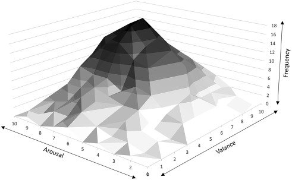

[Sign in to download full-size image](https://www.sciencedirect.com/user/login?returnURL=https%3A%2F%2Fwww.sciencedirect.com%2Ftopics%2Fpsychology%2Fcore-affect)

Fig. 12.3. Bivariate frequency distribution of affect for 535 individuals at an arbitrarily chosen moment.

After Yik, 1998 – cited by Russell, J. A. &amp; Barrett, L. F. (1999). Core affect, prototypical emotional episodes, and other things called emotion: Dissecting the elephant. *J. Pers. Soc. Psychol. 76*, 805–819.

The foregoing leads to a number of interesting hypotheses about affect: (1) Each of us may have a locus for affect (‘affect locus’ hereafter), broadly similar in principle to the idea of a happiness set point proposed by Sonja Lyubomirsky in ‘*The How of Happiness: A Scientific Approach to Getting the Life You Want’* (Lyubomirsky, 2007). (2) Knowingly or otherwise, we’re willing to expend effort, utilize resource and do ‘things’ that help to maintain or regain our affect locus. (3) Periodically, we need to extend beyond our affect locus along both dimensions in order to correct drift. (4) We’re motivated to do ‘things’ that maintain our affect locus or extend beyond it in either direction when circumstances dictate that doing so would make us feel good. (5) Through feedback mechanisms, we learn which actions help us to maintain or regain our affect locus (or extend beyond it) and which cause unwelcome drift.

[View chapter](https://www.sciencedirect.com/science/article/pii/B9780128211243000120)[Purchase book](https://www.elsevier.com/books/T/A/9780128211250)

## [Tailored Treatment Planning for Individuals With Personality Disorders](https://www.sciencedirect.com/science/article/pii/B9780128135211000151)

Johannes C. Ehrenthal, Cord Benecke, in [Case Formulation for Personality Disorders](https://www.sciencedirect.com/book/9780128135211/case-formulation-for-personality-disorders), 2019

### Assessing Conflictual Motivational Topics

Assessing conflicts is typically performed by looking for patterns and central topics throughout a patient’s life history. The interviewer pays close attention to what the patient considers important in life, how he/she differs from others with regard to motives, what are concomitant core affects and of course notable transference-countertransference constellations. In an individual with a neurotic conflict, motivational topics also define predetermined ‘breaking points’, where individuals with a specific conflictual theme usually experience failure, strain or the development of symptoms. For instance, a patient with a key insecurity in the area of self-worth may experience difficulties throughout his life whenever he is forced to show ‘how good he is’, for example exams or evaluations. Although the OPD encourages the clinician to decide if the patient’s problems are mostly attributable to dynamic motivational conflicts, structural deficits or a mixture of both, it is important to try to evaluate dominant motivational themes in patients with PDs as well. In patients with high or moderate levels of structural integration these topics and their conflictual representation is often clearly visible in the narratives, in dominant affects and countertransference reactions. In patients with low levels of structural integration, however, these motivational topics may be less clear, and serve a different function in the concurrent psychodynamics, as we will point out in more detail later in the chapter.

[View chapter](https://www.sciencedirect.com/science/article/pii/B9780128135211000151)[Purchase book](https://www.elsevier.com/books/T/A/9780128135211)

## [Emotional granularity in PTSD](https://www.sciencedirect.com/science/article/pii/B9780128160220000132)

Michael K. Suvak, ... Hilary Hodgdon, in [Emotion in Posttraumatic Stress Disorder](https://www.sciencedirect.com/book/9780128160220/emotion-in-posttraumatic-stress-disorder), 2020

### Psychological constructionism, PTSD, and emotional granularity

In addition to developing and producing initial support for the construct validity of emotional granularity, Lisa Feldman Barrett (e.g., Barrett, 2009a, 2009b, 2017) has developed a psychological constructionist model of emotion to capture the considerable variability of emotional states within (i.e., instances of fear for any individual varies considerable across situations; see Russell, 2003) and between (e.g., people differ in how they experience fear) individuals. According to her model, mental states (including emotions) are being constantly constructed via several biological and psychological processes. Barrett (e.g., Barrett, 2009a, 2017) often uses a cooking analogy to describe her model, with the biological and psychological processes representing different ingredients that are mixed together to produce a mental state, and the oven representing the context in which these ingredients meld into the final product. Important ingredients include core affect, physiological changes, memory, attention, knowledge (e.g., emotion concepts), and language.

To account for the heterogeneity in the expression of PTSD, Suvak and Barrett (2011) provided a psychological constructionist account of the brain processes that contribute to PTSD. They purported that PTSD arises from dysfunction in basic mechanisms (i.e., biological and psychological ingredients) related to salience and attention, hyperarousal, working memory, and long-term memory. A particular individual’s manifestation of PTSD is a function of (a) the amount and quality of basic ingredients involved (i.e., which basic mechanisms are involved and the nature of the dysfunction in these mechanisms), (b) the interaction among these ingredients and other ingredients that produce the mental states of PTSD, and (c) the context in which these basic ingredients are mixed together.

The exact psychological ingredients that contribute to emotional granularity have not been empirically investigated. However, it is likely that there is considerable overlap between the ingredients that contribute to PTSD and the ingredients that contribute to emotional granularity. Given the substantial heterogeneity in the expression of PTSD (see earlier), it is also likely that the ingredients associated with PTSD vary considerably across different manifestations of PTSD. The heterogeneity of PTSD may obscure overall associations between PTSD and emotional granularity. Therefore, future research on the association between PTSD and emotional granularity should include focus on identifying common ingredients contributing to these constructs.

Working memory is part of what Barrett (2009a) referred to as the attentional matrix, or different sources of attention that can change the rate of neural firing to focus attention and recruit necessary cognitive and behavioral resources in a given situation, a basic psychological ingredient that helps construct emotional experience. Working memory is an important executive function that controls attention and helps us negotiate the interplay of automatic and controlled processes by both maintaining multiple sources of information in an active state and manipulating this information to complete [complex cognitive tasks](https://www.sciencedirect.com/topics/psychology/complex-cognitive-task) (Barrett, Tugade, & Engle, 2004). While the relationship between emotional granularity and working memory/controlled attention has not been adequately empirically investigated, studies documenting associations between mindfulness and emotion differentiation provide an indirect link (Fogarty et al., 2015; Hill & Updegraff, 2012; Tong & Keng, 2017 & Van der Gucht et al., 2018). Van der Gucht et al. (2018) recently showed that a mindfulness intervention involving training participants to focus their attention on inner mental states and remain focused on them regardless of how unpleasant they were without judging or attempting to change them leads to significant increases in negative emotion differentiation. They also showed that changes in mindfulness skills accounted for subsequent changes in negative emotion differentiation, even when controlling for levels of negative affect. [Mindfulness](https://www.sciencedirect.com/topics/psychology/mindfulness) training has also been shown to increase [working memory capacity](https://www.sciencedirect.com/topics/psychology/working-memory-capacity) (Mrazek, Franklin, Phillips, Baird, & Schooler, 2013).

There is a wide body of research indicating that working memory processes are disrupted among adults with PTSD (see Polak, Witteveen, Reitsma, & Olff, 2012 and Aupperle, Melrose, Stein, & Paulus, 2012 for reviews), thought to arise from an overtaxing of cognitive resources that occurs when one is attempting to engage in complex cognitive tasks while simultaneously having to attend to and set aside distressing, intrusive trauma-related thoughts and memories (Schweizer & Dalgleish, 2011). A meta-analysis of 60 studies examining data from over 4000 individuals comparing those with PTSD, trauma-exposed comparison subjects, and healthy subjects found a significant working memory deficits in PTSD, with a medium effect size (*d* =−0.50; Scott et al., 2015). One study using an emotional working memory task, requiring adults with and without PTSD to remember lists of neutral words while processing either neutral sentences or sentences of trauma-related thoughts, showed that individuals with PTSD showed working memory deficits in an emotionally laden context but not in a neutral context (Schweizer & Dalgleish, 2011). Thus, disruptions in working memory exhibited by individuals in PTSD represent a potential link between PTSD and emotional granularity that warrants further investigation.

Core affect is another important ingredient in psychological constructionist models of emotion. Russell (2003) defined core affect as “A neurophysiological state that is consciously accessible as a simple, nonreflective feeling that is an integral blend of hedonic (pleasure-displeasure) and arousal (sleepy-activated) values (p. 147).” In other words, core affect is how you feel at any given moment, and it is always present even if it is often characterized by neutral valence and deactivated levels of arousal. Core affect can be experienced as a general mood, or it can be tied to a certain object or event contributing to an emotional episode.

The core affect of most mental disorders, in particular anxiety and mood disorders, is characterized by high levels of negative affectivity or high levels of nonspecific [emotional distress](https://www.sciencedirect.com/topics/psychology/emotional-distress) (captured by symptoms such as difficulty sleeping, irritability, and difficulty concentrating). Confirmatory factor analysis studies have demonstrated that these symptoms of nonspecific emotional distress (referred to as dysphoria or negative affectivity) linked PTSD to major depressive disorder and [generalized anxiety disorders](https://www.sciencedirect.com/topics/psychology/generalized-anxiety-disorder), two diagnosis that often co-occur with PTSD following exposures to [traumatic event](https://www.sciencedirect.com/topics/psychology/traumatic-event) (Byllesby, Charak, Durham, Wang, & Elhai, 2016; Grant, Beck, Marques, Palyo, & Clapp, 2008). Undifferentiated negative affect (sometimes referred to as negative affectivity, neuroticism, dysphoria, etc.) has been identified as a transdiagnostic construct associated with a variety of mental disorders (e.g., Krueger & Markon, 2006).

The tendency to experience nonspecific distress or negative affectivity has also been shown to be inversely related to emotion differentiation (e.g., Erbas et al., 2014), and as cited earlier, in one of the few studies that have longitudinally investigated emotion differentiation, Erbas et al., 2018) found that negative emotion differentiation varied significantly within individuals across time and that from day to day stress levels prospectively predicted negative motion differentiation, but negative emotion differentiation did not prospectively predict stress. Thus one possible link between PTSD and emotional granularity might be the tendency to experience nonspecific emotional distress, which may not be unique to PTSD but rather a transdiagnostic process common to several mental disorders characterized by high levels of negative affectivity. A comprehensive review of common psychological and biological ingredients that may link between PTSD and emotional granularity is beyond the scope of this chapter, but we want to note that adopting a psychological constructionist perspective may help elucidate the connection between PTSD and the ability to make fine-grained nuanced distinction among emotional states.

[View chapter](https://www.sciencedirect.com/science/article/pii/B9780128160220000132)[Purchase book](https://www.elsevier.com/books/T/A/9780128160220)

## [Measurement of consumer product emotions using questionnaires](https://www.sciencedirect.com/science/article/pii/B9780128211243000107)

Armand V. Cardello, Sara R. Jaeger, in [Emotion Measurement (Second Edition)](https://www.sciencedirect.com/book/9780128211250/emotion-measurement), 2021

### 10.3.3.1 Single-item questionnaires: affect grid and circumplex methods

Outside of sensory and consumer science, other emotion measurement approaches can be found. One method, the Affect Grid (Russell et al., 1989) was designed to be a quick method to assess affect along two dimensions, pleasure–displeasure and arousal–sleepiness. Although not specifically developed for application to foods/beverages, the Affect Grid is potentially suitable for any study that requires judgments about affect of either a descriptive or a subjective kind, but is especially suitable when there are many products or items to be screened. The Affect Grid is presented as a square consisting of 9 × 9 smaller squares that are anchored at the extreme ends by selected emotion words to indicate, for example, high arousal and unpleasant feelings (stress), high arousal and pleasant feelings (excitement), low arousal and pleasant feelings (relaxation), etc. Participants select one of the 81 squares to indicate how they are feeling, resulting in rapid single-item scaling. If many products need to be screened, this single-item scale that simultaneously provides pleasure and arousal scores for each object, may be considered (Jiang, King, & Prinyawiwatkul, 2014).

The 12-point circumplex structure of core affect (Russell, 1980; Russell et al., 1989; Yik, Russell, & Steiger, 2011) spans the same 2-dimensional space as the Affect Grid, but enables a more detailed capture of affect, mood and emotion than the Affect Grid. The circumplex approach uses 12 dimensions, which are positioned in a circumplex structure around the circumference of a circle and are rated on a 4-point or 5-point scale.

Combining the single-item scale characteristic of the Affect Grid, with the 12-point circumplex structure of core affect, Jaeger and colleagues created a rapid emotion measurement approach (see Jaeger, Spinelli, et al., 2018; Jaeger, Xia, et al., 2019; Jaeger, Roigard, 2020). The emotion circumplex ballot is shown in Fig. 10.2. Specific words pairs are arranged around the perimeter of the circle, so that those on the right represent positive feelings/emotions and those on the left represent negative feelings/emotions. The upper and lower parts of the figure represent feelings/emotions that are higher and lower in emotional activation, respectively. These elements of the circumplex ballot are explained to the consumer prior to use, along with the fact that pairs of emotion words with more similar meaning are positioned closer to each other on the figure than those with very different meanings. Participants then simply select one of the 12 sets of word pairs on the circumplex to indicate how they are currently feeling. The data from the circumplex ballot are analyzed in terms of citation frequencies for each dimension. Results from an application of the circumplex approach to a household care product (liquid soap) is shown in Table 10.9. In this study two variants of liquid soap were presented to 94 New Zealand consumers in a Central Location Test. As can be seen in this table, clear differences in the emotional character of the samples were reflected in the total citation frequencies for the 12 emotion dimensions of the circumplex. Of additional importance to highlight is that the data collection for this study took less than 5 min, which includes the break between samples. As such the circumplex method constitutes a very rapid method for collection of product emotion data. Recent studies that have used this circumplex approach include Cardello et al. (2016); Jaeger, Lee, et al. (2017); Jaeger, Vidal, Kam, and Ares (2017); Jaeger, Spinelli, et al. (2018); Jaeger, Xia, et al. (2019); Jaeger, Lee, et al. (2019). The reader is referred to the chapter *Methodological Issues in Consumer Product Emotion Research Using Emotion Word Questionnaires*, this volume, for a more detailed exposition of the circumplex approach.

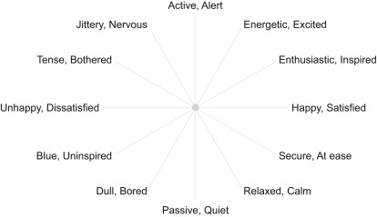

[Sign in to download full-size image](https://www.sciencedirect.com/user/login?returnURL=https%3A%2F%2Fwww.sciencedirect.com%2Ftopics%2Fpsychology%2Fcore-affect)

Fig. 10.2. Rapid circumplex emotion questionnaire.

|  | Sample 1 | Sample 2 |
| --- | --- | --- |
| Curious, Alert | 11 | 15 |
| Energetic, Excited | 11 | 5 |
| Enthusiastic, Inspired | 10 | 3 |
| Content, Pleased | 18 | 6 |
| Soothed, Peaceful | 27 | 5 |
| Calm, Tranquil | 15 | 4 |
| Passive, Quiet | 2 | 6 |
| Dull, Sluggish | 1 | 11 |
| Sad, Gloomy | 0 | 7 |
| Unhappy, Dissatisfied | 2 | 20 |
| Upset, tense | 2 | 10 |
| Anxious, Jittery | 1 | 6 |

Data from 94 New Zealand consumers.

[View chapter](https://www.sciencedirect.com/science/article/pii/B9780128211243000107)[Purchase book](https://www.elsevier.com/books/T/A/9780128211250)

## [Methodological issues in consumer product emotion research using questionnaires](https://www.sciencedirect.com/science/article/pii/B9780128211243000156)

Sara R. Jaeger, Armand V. Cardello, in [Emotion Measurement (Second Edition)](https://www.sciencedirect.com/book/9780128211250/emotion-measurement), 2021

### 15.7 A single-response circumplex-inspired emotion word questionnaire

By now it should be clear that emotion word questionnaires are popular, flexible, and easy to implement. They are also in evolution. The present section is dedicated to a questionnaire that is very different from those discussed until now. It uses emotion words, but rather than presenting these in a list, the arrangement of words is based on a circumplex model of core affect that spans the dimensions of pleasure and arousal (Fig. 15.6). Readers are referred to Jaeger, Roigard, et al. (2020) and Jaeger, Roigard, & Chheang (2021) for additional details, as well as Cardello and Jaeger (2016) who first presented this circumplex-inspired questionnaire.

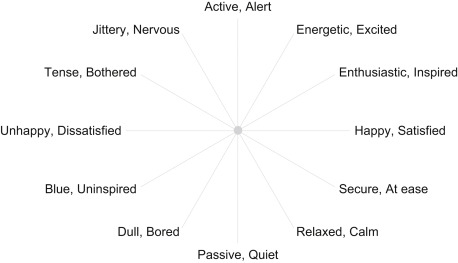

[Sign in to download full-size image](https://www.sciencedirect.com/user/login?returnURL=https%3A%2F%2Fwww.sciencedirect.com%2Ftopics%2Fpsychology%2Fcore-affect)

Jaeger, Roigard, et al. (2020) performed a methodological characterization of the circumplex-inspired emotion questionnaire involving 23 studies (104–270 consumers per study) and a very broad range of F&B products and categories. Herein they demonstrated suitability for use with tasted stimuli, written stimuli and image stimuli. New Zealand and Chinese consumers took part in the studies, pointing to versatility of the questionnaire in multiple cultures. It was further reported that responses appeared to be repeatable, and based on the criterion of the RV coefficient being equal to or greater than 0.95 stability could be achieved with as low as 30 consumers despite only obtaining a single response per consumer per stimulus. Mirroring past research, and intuitively making sense, it was also reported that the degree of differences between stimuli in a study influenced discrimination, which was larger when stimuli were more different.

Overall, at this stage in the questionnaire’s stage of application and development there appears to be no reason to not regard it as a welcome addition to the existing collection of emotion word questionnaires for product emotion research. To support uptake, the questionnaire’s performance relative to existing approaches in emotion measurement needs to be understood, as does potential weaknesses. Lack of specificity and limited ability to in-depth profile stimuli are contenders in this regard. There is a need to determine goodness-of-fit to the underpinning circumplex model and possibly develop variants that improve hereupon if needed.

[View chapter](https://www.sciencedirect.com/science/article/pii/B9780128211243000156)[Purchase book](https://www.elsevier.com/books/T/A/9780128211250)